# Introdução à economia

Aula 24 - Desemprego

Prof. Roberto de Freitas Neder

## Aula 24: roteiro

**Desemprego** · Mankiw, capítulo 28 · UnB

- Medir o desemprego
- Busca e transições
- Pisos, sindicatos e emprego
- Por que empresas pagam mais
- Conclusão
- Exercícios de concursos públicos

Use as setas para trocar de slide. Nas páginas longas, role o conteúdo. As respostas das atividades ficam fechadas até o clique.

## 01 - Trabalho disponível e emprego

Uma economia pode produzir mais e ainda manter pessoas procurando trabalho. Para compreender esse fenômeno, precisamos primeiro definir quem está ocupado, quem está desocupado e quem está fora da força de trabalho.

O capítulo examina a mensuração e quatro explicações para a persistência do desemprego: busca de emprego, salário mínimo, sindicatos e salários de eficiência.

Os mecanismos não atuam com a mesma intensidade em todos os mercados. A análise começa identificando qual problema ocorre e em quais condições.

**Base:** Mankiw, capítulo 28, *Unemployment*, pp. 577 a 600. PDF: pp. 606 a 629.

← Menu

## 02 - Três situações distintas

| Situação | Ideia básica |
| --- | --- |
| Ocupado | Realizou trabalho ou atende às condições de vínculo/afastamento da pesquisa |
| Desocupado | Está sem ocupação, procura trabalho e está disponível, conforme a metodologia |
| Fora da força de trabalho | Não se enquadra nas duas categorias anteriores |

Estudar, aposentar-se ou realizar cuidado não remunerado não determina automaticamente a classificação. Uma pessoa pode estudar e estar ocupada ou procurando emprego.

**Desocupação não é simplesmente “não ter carteira assinada” nem “não trabalhar”.** Os critérios de busca e disponibilidade são decisivos.

← Menu

## 03 - Força de trabalho e indicadores

$$FT=O+D$$
$$u=\frac{D}{O+D}\times100$$
$$Participacao=\frac{FT}{PIA}\times100\qquad Ocupacao=\frac{O}{PIA}\times100$$

$O$ representa ocupados, $D$ desocupados e $PIA$ a população em idade de trabalhar no universo da pesquisa.

A taxa de desocupação usa a força de trabalho como denominador. A taxa de participação utiliza a população em idade de trabalhar.

Confundir esses denominadores altera a interpretação econômica e é um erro frequente em exercícios.

← Menu

## 04 - Exemplo completo de classificação

**População didática em idade de trabalhar: 1.000 pessoas.** Há 600 ocupadas, 100 desocupadas e 300 fora da força de trabalho.

| Indicador | Cálculo | Resultado |
| --- | --- | --- |
| Força de trabalho | $600+100$ | 700 |
| Taxa de desocupação | $100/700$ | 14,29% |
| Taxa de participação | $700/1.000$ | 70% |
| Nível de ocupação | $600/1.000$ | 60% |

Desocupados são 10% da população do exemplo, mas a **taxa de desocupação é 14,29%**, porque usa outro denominador.

← Menu

## 05 - Uma queda que exige investigação

No exemplo anterior, 50 desocupados deixam de procurar emprego e passam a ficar fora da força de trabalho. Nenhuma nova ocupação foi criada.

Agora, $O=600$, $D=50$ e $FT=650$.

$$u=50/650\approx7{,}69\%$$

A taxa caiu de 14,29% para 7,69%, mas o emprego ficou constante e a participação caiu de 70% para 65%.

**Desalento** envolve desistir de procurar por razões ligadas às condições do mercado, segundo critérios específicos. Nem toda pessoa fora da força de trabalho está desalentada.

← Menu

## 06 - Entrada na força de trabalho

Suponha, agora, que pessoas antes fora da força de trabalho comecem a procurar uma ocupação.

Mesmo com criação de vagas, a taxa de desocupação pode aumentar temporariamente se a entrada de candidatos for maior que a absorção em postos.

Por isso, o diagnóstico deve combinar taxa de desocupação, ocupação, participação e horas trabalhadas.

O capítulo discute mudanças históricas na participação de homens e mulheres. Essas mudanças dependem de educação, cuidado, normas sociais, estrutura familiar e oportunidades de trabalho, além da remuneração.

← Menu

## 07 - Brasil e Estados Unidos: conceitos próximos

O capítulo utiliza as estatísticas norte-americanas e a pesquisa domiciliar do BLS. No Brasil, a PNAD Contínua, do IBGE, é uma referência para medir trabalho e desocupação.

Os universos etários e detalhes operacionais diferem. Na PNAD Contínua, os indicadores de trabalho consideram pessoas de **14 anos ou mais**. O capítulo norte-americano utiliza o universo de 16 anos ou mais.

Antes de comparar taxas, consulte definições, período de referência, cobertura e ajustes.

[IBGE: desemprego e conceitos](https://www.ibge.gov.br/explica/desemprego.php)

← Menu

## 08 - Informalidade e subutilização

Uma pessoa com trabalho informal pode estar **ocupada**. Informalidade e desocupação medem problemas diferentes.

Uma pessoa ocupada também pode desejar e estar disponível para trabalhar mais horas. A insuficiência de horas é uma forma de subutilização, conforme os critérios da pesquisa.

Medidas ampliadas incorporam dimensões que a taxa de desocupação não capta, inclusive a força de trabalho potencial.

Uma leitura adequada observa qualidade, renda, estabilidade e jornada do emprego. A existência de alguma ocupação não garante trabalho suficiente ou condições dignas.

← Menu

## 09 - Pessoas e postos de trabalho

Pesquisas domiciliares classificam pessoas. Pesquisas com estabelecimentos e registros administrativos podem contar postos ou vínculos.

Uma pessoa com dois empregos pode aparecer como uma pessoa ocupada e dois vínculos. Autônomos e ocupações informais podem ter cobertura diferente entre fontes.

O capítulo chama atenção para a interpretação de números de emprego divulgados a partir de pesquisas distintas.

**Divergência entre medidas não significa automaticamente erro.** É necessário verificar o que cada uma conta, sua cobertura e o período a que se refere.

← Menu

## 10 - Duração e fotografia do desemprego

Muitos episódios de desemprego podem ser curtos, enquanto grande parte do tempo total de desemprego pertence a episódios longos.

**Exemplo:** oito pessoas ficam desocupadas por um mês e uma pessoa fica por 12 meses.

Há nove episódios, dos quais oito são curtos. Mas a pessoa de longa duração responde por $12/(8+12)=60\%$ dos 20 meses-pessoa de desocupação.

Uma pesquisa realizada em uma data tem maior chance de encontrar episódios longos. Por isso, frequência de episódios e peso no estoque de desocupados são medidas distintas.

← Menu

## 11 - Jogo rápido: o denominador importa

Uma população tem 800 pessoas em idade de trabalhar: 450 ocupadas, 50 desocupadas e 300 fora da força.

1. Qual é a taxa de desocupação?
2. Qual é a taxa de participação?
3. Se 20 desocupados conseguirem trabalho, sem outras mudanças, qual será a nova taxa de desocupação?

**Conferir respostas**

1. $50/500=10\%$. 2. $500/800=62{,}5\%$. 3. A força continua em 500, os desocupados caem para 30 e a taxa passa a 6%. Agora houve aumento efetivo da ocupação.

← Menu

## 12 - Friccional, estrutural e cíclico

**Friccional:** decorre do tempo necessário para encontrar uma combinação adequada entre trabalhadores e vagas.

**Estrutural:** relaciona-se a desencontros persistentes e, na apresentação do capítulo, a salários acima do nível que equilibraria oferta e demanda em certos mercados.

**Cíclico:** acompanha flutuações da atividade em torno de sua trajetória de longo prazo. Recessões podem reduzir fortemente as contratações.

As categorias organizam explicações, mas situações concretas podem combinar mecanismos. O capítulo concentra-se na persistência do desemprego, deixando o estudo detalhado das flutuações para capítulos posteriores.

← Menu

## 13 - Taxa natural não significa imutável

A taxa natural representa, no modelo, o nível de desemprego em torno do qual a economia flutua quando se consideram suas condições estruturais e friccionais.

Ela **não é necessariamente zero, justa ou inevitável em seu valor atual**. Pode mudar com instituições, composição da força de trabalho, informação e eficiência da busca.

A taxa observada pode ficar acima ou abaixo dessa referência por fatores cíclicos.

Não se deve identificar a taxa natural diretamente com uma única estatística publicada. Sua estimação depende de modelo e envolve incerteza.

← Menu

## 14 - A busca por uma combinação adequada

Trabalhadores diferem em habilidades, localização e preferências. Vagas diferem em tarefas, horários, exigências e remuneração.

Encontrar uma combinação leva tempo. Uma vaga pode existir em outra cidade ou exigir competências que o candidato ainda não possui.

Informação incompleta explica por que vagas abertas e pessoas desocupadas podem coexistir.

Trocas de emprego e entrada de novos trabalhadores mantêm esse processo ativo mesmo quando a economia cresce. Eliminar todo tempo de busca não seria necessariamente desejável se levasse a combinações muito ruins.

← Menu

## 15 - Mudanças setoriais

Uma mudança das preferências dos consumidores pode ampliar vendas e contratação em um setor e reduzir em outro.

Trabalhadores não se transferem instantaneamente. Podem precisar de informação, deslocamento ou formação.

O capítulo usa mudanças entre setores e regiões para explicar a persistência de desemprego friccional.

Quanto mais profundo e duradouro o desencontro de competências ou localização, mais importante se torna a dimensão estrutural. A classificação não dispensa investigar por que a transição está difícil.

← Menu

## 16 - Políticas de intermediação e formação

Serviços de emprego podem divulgar vagas e aproximar candidatos de empresas. Formação e requalificação podem ampliar as combinações possíveis.

A eficácia depende de conhecer a demanda por competências, oferecer condições de participação e acompanhar resultados.

Treinar sem considerar vagas, transporte ou responsabilidades de cuidado pode produzir poucos efeitos sobre inserção.

Uma avaliação deve distinguir participação no curso, obtenção de emprego, duração do vínculo e mudança de renda. Programas diferentes podem ajudar grupos diferentes.

← Menu

## 17 - Seguro-desemprego e busca

O seguro-desemprego protege parte da renda durante uma transição. Pode permitir uma busca mais cuidadosa e reduzir a necessidade de aceitar imediatamente uma combinação inadequada.

Ao mesmo tempo, a manutenção do benefício pode alterar o incentivo para procurar ou aceitar ofertas e prolongar a duração observada.

O efeito líquido depende do desenho, do mercado e das restrições financeiras. **Maior duração não mede, sozinha, o benefício ou o custo social do programa.**

É preciso avaliar proteção, qualidade do emprego encontrado, esforço de busca, cobertura e financiamento.

← Menu

## 18 - Fluxos e estoque de desempregados

Como apoio quantitativo, suponha força de trabalho constante. Seja $s$ a proporção dos ocupados que perde o emprego e $f$ a proporção dos desocupados que encontra trabalho em um período.

No estado estacionário, entradas e saídas se igualam:

$$sO=fD\quad\Rightarrow\quad u=\frac{s}{s+f}$$

Com $s=2\%$ e $f=18\%$, a taxa estacionária é $0{,}02/0{,}20=10\%$.

Essa extensão simplifica a análise: ignora movimentos de entrada e saída da força de trabalho, importantes nos dados reais.

← Menu

## 19 - Salário mínimo no modelo competitivo

Um piso abaixo do salário de equilíbrio não altera o resultado do modelo básico. Um piso **acima** desse valor é vinculante.

Nesse segundo caso, a quantidade de trabalho ofertada aumenta e a quantidade demandada diminui. O excesso de oferta representa pessoas dispostas a trabalhar ao piso que não obtêm um posto.

O modelo não afirma que toda pessoa desocupada perdeu um emprego: algumas podem ter entrado na busca atraídas pelo salário maior.

Os efeitos dependem de elasticidades, cobertura, cumprimento e poder dos empregadores.

← Menu

## 20 - Piso salarial: leitura do gráfico

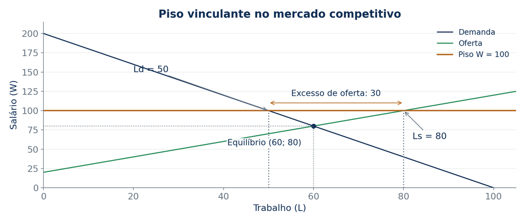

Salário mínimo de 100 acima do equilíbrio de 80: demanda de 50 trabalhadores, oferta de 80 e excesso de oferta de 30.

Fonte: elaboração didática. Dados hipotéticos, salvo indicação expressa.

**Exemplo:** $D:W=200-2L$ e $S:W=20+L$. Com piso de 100, $L_D=50$ e $L_S=80$.

Emprego cai de 60 para 50. O excesso de oferta é 30, e não apenas os dez postos a menos.

← Menu

## 21 - Elasticidades e diferentes mercados

Se a demanda por trabalho reage pouco ao salário, uma elevação do piso pode produzir variação relativamente pequena na quantidade demandada. Com demanda mais elástica, a reação tende a ser maior.

Empresas também podem ajustar horas, preços, benefícios, treinamento e tecnologia. Por isso, contar empregos é apenas parte da avaliação.

O capítulo enfatiza que o salário mínimo afeta mais diretamente os trabalhadores próximos ao piso e não explica sozinho todo desemprego.

Uma política deve ser examinada no mercado em que efetivamente atua.

← Menu

## 22 - O caso do monopsônio

Retomando a aula 22, um empregador com poder de compra pode pagar abaixo do valor marginal e contratar menos que na referência competitiva.

Nesse contexto, um piso situado em um intervalo adequado pode aumentar simultaneamente remuneração e emprego, ao modificar o custo marginal de contratação.

Um piso suficientemente alto ainda pode reduzir emprego. O resultado não é “qualquer mínimo ajuda”, mas **o efeito depende da estrutura de mercado e do nível escolhido**.

Evidência empírica é necessária para avaliar qual mecanismo predomina em cada situação.

← Menu

## 23 - Sindicatos e negociação coletiva

Sindicatos representam trabalhadores na negociação de salários, benefícios e condições de trabalho. A negociação coletiva altera a forma como empregadores e empregados estabelecem o contrato.

O capítulo compara essa ação conjunta ao poder de mercado dos ofertantes de trabalho e discute a possibilidade de greve.

No modelo competitivo simples, uma remuneração negociada acima do equilíbrio pode reduzir emprego no setor e deslocar candidatos para outros mercados.

Essa é uma dimensão do problema. Também é preciso considerar poder dos empregadores, segurança, informação, redução de conflitos e cumprimento de direitos.

← Menu

## 24 - O debate sobre sindicatos

**Crítica apresentada no livro:** ganhos dos trabalhadores cobertos podem vir acompanhados de menos contratações e pressão sobre salários de trabalhadores fora da negociação.

**Argumento favorável apresentado no livro:** a negociação coletiva pode contrabalançar poder empresarial e melhorar condições que contratos individuais não conseguem assegurar.

Sindicatos também podem transmitir informação e negociar ajustes de organização produtiva.

O resultado depende das instituições e do funcionamento da negociação. A análise não deve presumir que toda atuação sindical produza o mesmo efeito em qualquer mercado.

← Menu

## 25 - Salários de eficiência

Na teoria dos salários de eficiência, a própria empresa pode preferir pagar acima do nível que equilibraria oferta e demanda.

A remuneração altera produtividade, custos de seleção, rotatividade ou esforço. Reduzi-la pode piorar o resultado da firma, mesmo quando há pessoas dispostas a trabalhar por menos.

Assim, o desemprego pode persistir sem que uma lei ou sindicato impeça o corte salarial.

O capítulo apresenta quatro mecanismos. Eles precisam ser distinguidos porque dependem de problemas econômicos diferentes.

← Menu

## 26 - Saúde e nutrição

Quando a renda é insuficiente para alimentação e saúde adequadas, remuneração maior pode melhorar a capacidade de trabalho.

Nessas condições, reduzir salários pode comprometer produtividade e elevar afastamentos. A economia aparente no pagamento pode ser compensada por perdas de produção.

O mecanismo é mais relevante onde restrições materiais afetam fortemente saúde e nutrição. Não se deve supor que tenha a mesma importância em todos os níveis salariais.

Além do interesse da firma, saúde e alimentação têm valor para as pessoas independentemente de seus efeitos produtivos.

← Menu

## 27 - Rotatividade e custos de treinamento

Uma empresa perde recursos ao selecionar e treinar substitutos. Novos trabalhadores também podem precisar de tempo para atingir o desempenho da equipe experiente.

Salários maiores podem reduzir saídas voluntárias e preservar conhecimento específico.

**Exemplo didático:** se remuneração adicional custa menos que a redução esperada das despesas de substituição, a política pode ser rentável.

A decisão depende de frequência de saídas, custo de treinamento e alternativas dos trabalhadores. Pagar mais não elimina toda rotatividade, que também responde a condições de trabalho e perspectivas profissionais.

← Menu

## 28 - Qualidade dos candidatos

Empregadores não observam perfeitamente a produtividade antes da contratação. O salário anunciado influencia quem se candidata.

Uma redução pode afastar candidatos com melhores alternativas externas. Se a qualidade média do conjunto cair suficientemente, o corte não compensa.

Esse mecanismo se relaciona à **seleção adversa**: informação privada sobre características dos candidatos afeta a composição do mercado.

Ele não permite avaliar a capacidade de uma pessoa apenas pela renda anterior. Trata-se de uma hipótese sobre seleção e oportunidades, que precisa ser investigada.

← Menu

## 29 - Esforço e monitoramento

Monitorar perfeitamente o esforço é caro ou impossível em muitas atividades. Uma remuneração acima das alternativas disponíveis aumenta a perda associada a uma demissão.

Essa diferença pode incentivar esforço e reduzir comportamentos que o empregador não observa diretamente. O mecanismo está ligado ao **risco moral**.

Na formulação do modelo, algum desemprego torna menos imediata a obtenção de outro posto equivalente.

Esse resultado explica um incentivo da firma. Não constitui recomendação de produzir sofrimento ou desemprego como objetivo de política pública.

← Menu

## 30 - Henry Ford e o salário elevado

O capítulo usa o pagamento de US$ 5 por dia anunciado por Ford em 1914 para ilustrar a discussão sobre remuneração, procura por vagas e rotatividade.

A hipótese econômica é que pagar mais poderia reduzir custos de substituição, melhorar esforço e estabilizar a força de trabalho em uma organização produtiva exigente.

O episódio histórico envolvia condições e regras próprias. Não prova que qualquer empresa possa elevar salários na mesma proporção e obter o mesmo resultado.

Casos ajudam a formular mecanismos. Identificar seu efeito exige comparar custos, produtividade e alternativas plausíveis.

← Menu

## 31 - Jogo rápido: qual mecanismo?

Associe cada situação a uma explicação.

1. Demitidos e vagas compatíveis levam semanas para se encontrar.
2. A empresa paga mais para reduzir pedidos de demissão.
3. Salário maior atrai candidatos com melhores alternativas.
4. Uma recessão derruba vendas e contratações em muitos setores.

**Conferir respostas**

1. Busca e desemprego friccional. 2. Salário de eficiência por rotatividade. 3. Salário de eficiência por seleção de candidatos. 4. Desemprego cíclico. A política adequada depende de reconhecer qual restrição está operando.

← Menu

## 32 - Conclusão: diagnosticar para agir

A taxa de desocupação é indispensável, mas precisa ser lida junto com participação, ocupação, horas e condições do trabalho. Uma queda pode resultar de contratação ou de saída da força de trabalho.

Busca, desencontros, instituições e decisões empresariais ajudam a explicar por que desemprego persiste. As flutuações da atividade acrescentam uma dimensão cíclica.

**Não existe uma única causa nem um único instrumento para todos os casos.** Intermediação, formação, proteção de renda, regulação e políticas de atividade respondem a problemas diferentes.

O objetivo da análise é conectar conceitos a melhores condições de inserção, renda e vida.

← Menu

## Exercícios de concursos públicos

Oito exercícios selecionados. Nos itens de julgamento, use **C (certo/verdadeiro)** ou **E (errado/falso)**. Leia os enunciados antes de abrir as respostas. As fontes e as adaptações estão identificadas em cada questão.

### Questão 01

FGV, ALE/PR, Analista Legislativo, Economista, 2024, tipo 1 · questão 48

Classifique como V/F: inovação pode gerar desemprego estrutural; custos de busca geram friccional; recessão produz conjuntural.

1. V, V, V
2. V, V, F
3. V, F, V
4. F, V, V
5. F, F, F

Redação sintetizada para uso didático; dados e resposta preservados.

[Prova original](https://conhecimento.fgv.br/sites/default/files/concursos/analista-legislativo-economistae2cns04-tipo-1.pdf) · [Gabarito oficial](https://conhecimento.fgv.br/sites/default/files/concursos/ale-pr-gabarito-definitivo-cargos-do-edital-2.pdf)

Resposta comentada

### Questão 02

CESPE, Câmara dos Deputados, Analista Legislativo / Assistente Técnico, FC de Consultor Legislativo, Área V, 2002 · questão 72, 1º item

A taxa de desemprego é a relação percentual entre as pessoas que procuram emprego e a quantidade de ocupados.

**( ) C ( ) E**

Item original C/E, com normalização de espaçamento. A prova autoriza reprodução com indicação da fonte.

[Prova original](https://cdn.cebraspe.org.br/concursos/_antigos/2003/camaradosdeputados/ARQUIVOS/area_05.pdf) · [Gabarito oficial](https://cdn.cebraspe.org.br/concursos/_antigos/2003/CAMARADOSDEPUTADOS/Arquivos/Gab_Def_CD.pdf)

Resposta comentada

### Questão 03

CESPE, Câmara dos Deputados, Analista Legislativo / Assistente Técnico, FC de Consultor Legislativo, Área V, 2002 · questão 72, 5º item

A diferença entre a população em idade ativa (PIA) e a população economicamente ativa (PEA) está no número de pessoas que não participam do mercado de trabalho, ou seja, que não estão ocupadas nem à procura de trabalho.

**( ) C ( ) E**

Item original C/E, com normalização de espaçamento. A prova autoriza reprodução com indicação da fonte.

[Prova original](https://cdn.cebraspe.org.br/concursos/_antigos/2003/camaradosdeputados/ARQUIVOS/area_05.pdf) · [Gabarito oficial](https://cdn.cebraspe.org.br/concursos/_antigos/2003/CAMARADOSDEPUTADOS/Arquivos/Gab_Def_CD.pdf)

Resposta comentada

### Questão 04

CESPE, Senado Federal, Consultor Legislativo, Área 14, 2002 · questão 55, 5º item

A taxa natural de desemprego é aquela que prevalece quando a economia está produzindo no nível de seu produto potencial.

**( ) C ( ) E**

Item original C/E, com normalização de espaçamento. A prova autoriza reprodução com indicação da fonte.

[Prova original](https://cdn.cebraspe.org.br/concursos/_antigos/2002/senado/Arquivos/area_14_LEGISL_1Et.pdf) · [Gabarito oficial](https://cdn.cebraspe.org.br/concursos/_antigos/2002/senado/Arquivos/Gab_Def-SENADO.pdf)

Resposta comentada

### Questão 05

CESPE, Senado Federal, Consultor Legislativo, Área 14, 2002 · questão 65, 1º item

No longo prazo, a taxa natural de desemprego, em geral, é fixa. Já no curto prazo, ela pode variar em função de alterações no ambiente macroeconômico.

**( ) C ( ) E**

Item original C/E, com normalização de espaçamento. A prova autoriza reprodução com indicação da fonte.

[Prova original](https://cdn.cebraspe.org.br/concursos/_antigos/2002/senado/Arquivos/area_14_LEGISL_1Et.pdf) · [Gabarito oficial](https://cdn.cebraspe.org.br/concursos/_antigos/2002/senado/Arquivos/Gab_Def-SENADO.pdf)

Resposta comentada

### Questão 06

CESPE, Senado Federal, Consultor Legislativo, Área 14, 2002 · questão 67, 4º item

Um pressuposto fundamental do modelo de salário-eficiência é que a redução do salário pago por uma empresa em relação às demais acarreta a redução na produtividade de seus trabalhadores.

**( ) C ( ) E**

Item original C/E, com normalização de espaçamento. A prova autoriza reprodução com indicação da fonte.

[Prova original](https://cdn.cebraspe.org.br/concursos/_antigos/2002/senado/Arquivos/area_14_LEGISL_1Et.pdf) · [Gabarito oficial](https://cdn.cebraspe.org.br/concursos/_antigos/2002/senado/Arquivos/Gab_Def-SENADO.pdf)

Resposta comentada

### Questão 07

CESPE, Senado Federal, Consultor Legislativo, Área 14, 2002 · questão 70, 4º item

No caso de um empregador monopsonista que fixa um salário abaixo do produto marginal do trabalho, a fixação do salário mínimo no nível de equilíbrio competitivo acarreta redução do nível de emprego da economia.

**( ) C ( ) E**

Item original C/E, com normalização de espaçamento. A prova autoriza reprodução com indicação da fonte.

[Prova original](https://cdn.cebraspe.org.br/concursos/_antigos/2002/senado/Arquivos/area_14_LEGISL_1Et.pdf) · [Gabarito oficial](https://cdn.cebraspe.org.br/concursos/_antigos/2002/senado/Arquivos/Gab_Def-SENADO.pdf)

Resposta comentada

### Questão 08

CESPE, Senado Federal, Consultor Legislativo, Área 14, 2002 · questão 70, 2º item

O efeito final de uma elevação do salário mínimo sobre o emprego depende, entre outros fatores, da elasticidade da demanda por trabalho: quanto mais elástica for a demanda, maior será o efeito negativo.

**( ) C ( ) E**

Item original C/E, com normalização de espaçamento. A prova autoriza reprodução com indicação da fonte.

[Prova original](https://cdn.cebraspe.org.br/concursos/_antigos/2002/senado/Arquivos/area_14_LEGISL_1Et.pdf) · [Gabarito oficial](https://cdn.cebraspe.org.br/concursos/_antigos/2002/senado/Arquivos/Gab_Def-SENADO.pdf)

Resposta comentada

**Gabarito resumido e resoluções comentadas**

| Questão | 01 | 02 | 03 | 04 | 05 | 06 | 07 | 08 |
| --- | --- | --- | --- | --- | --- | --- | --- | --- |
| Resposta | A | E | C | C | E | C | E | C |

**Questão 01: A**

As três associações estão corretas. Mudanças nas habilidades exigidas geram desencontro estrutural; tempo e custos de encontro entre vagas e pessoas geram fricção; recessões reduzem a demanda de trabalho e geram componente cíclico.

Voltar ao enunciado

**Questão 02: E**

O denominador é a força de trabalho, isto é, ocupados mais desocupados: $u=U/(E+U)$. Usar apenas ocupados superestima a taxa e produz um indicador diferente.

Voltar ao enunciado

**Questão 03: C**

A diferença corresponde às pessoas fora da força de trabalho. Elas não devem ser tratadas automaticamente como desempregadas. A classificação operacional também verifica disponibilidade e procura segundo a metodologia da pesquisa.

Voltar ao enunciado

**Questão 04: C**

Produzir no nível potencial é compatível com desemprego friccional e estrutural. Pleno emprego não exige desemprego zero, nem significa ausência de pessoas vulneráveis ou de subutilização em outros indicadores.

Voltar ao enunciado

**Questão 05: E**

A taxa natural não é uma constante imutável. Instituições, composição da força de trabalho, tecnologia de busca e organização dos mercados podem mudar sua magnitude ao longo do tempo.

Voltar ao enunciado

**Questão 06: C**

Nos modelos de salário de eficiência, reduzir a remuneração pode prejudicar esforço, retenção, qualidade das contratações ou saúde. Por isso a firma pode escolher um salário acima do que igualaria oferta e demanda.

Voltar ao enunciado

**Questão 07: E**

No monopsonista simples, o piso fixado no nível competitivo pode aumentar o emprego relativamente ao equilíbrio monopsonista. O enunciado erra ao prever redução. Um piso excessivamente alto pode produzir outro resultado, portanto a conclusão depende de onde ele é fixado.

Voltar ao enunciado

**Questão 08: C**

No modelo competitivo com piso efetivamente vinculante, demanda mais elástica implica maior redução da quantidade de trabalho demandada diante de uma mesma elevação proporcional do salário. Essa previsão é condicional ao modelo e não substitui avaliação empírica.

Voltar ao enunciado

← Menu